# scRNASeq_Liver

- Show All Code
- Hide All Code
- View Source

Author

André Barros & Helena Cabaço

Published

October 24, 2025

# scRNASeq Analysis Liver - Steady State vs NAFLD

This notebook is focused on the analysis of a scRNASeq dataset of liver, comparing samples from controls (steady state) and NAFLD.

```r
setwd("C:/Users/asbarros/OneDrive - FUNDAÇÃO GIMM - GULBENKIAN INSTITUTE FOR MOLECULAR MEDICINE/ADA/ZZ_Tutorials/AutumSchool_scRNASeq/Group_Project/")

sce = readRDS("00_Dataset/MouseLiverNAFLD.RDS")
sce
```

```
An object of class Seurat
25127 features across 30987 samples within 1 assay
Active assay: RNA (25127 features, 0 variable features)
 1 layer present: counts
```

```r
orig_metadata = read.table("01_OriginalMetadata/GSE166504_cell_metadata.20220204.tsv",sep="\t",header=T) %>%
  mutate(UniqueID = paste0(FileName,"_",CellID))

sce@meta.data = sce@meta.data %>%
              mutate(UniqueID = paste0(FileName,"_",CellID))

orig_metadata = orig_metadata %>%
  filter(UniqueID %in% sce@meta.data$UniqueID)


#all(orig_metadata$UniqueID == sce@meta.data$UniqueID)

sce@meta.data$celltype = orig_metadata$CellType


metadata = sce@meta.data

table(metadata$animal,metadata$sort,metadata$time)
```

```
, ,  = 15weeks


          Hepatocyte  NPC
  Animal1       2000 2000
  Animal2       2000 2000
  Animal3       2000 2000

, ,  = 30weeks


          Hepatocyte  NPC
  Animal1       2000 2000
  Animal2       1987 2000
  Animal3          0 2000

, ,  = Chow


          Hepatocyte  NPC
  Animal1       1000 2000
  Animal2       1000 2000
  Animal3       1000 2000
```

```r
table(metadata$capture,metadata$sort,metadata$time)
```

```
, ,  = 15weeks


           Hepatocyte  NPC
  Capture1       3000 3000
  Capture2       3000 3000

, ,  = 30weeks


           Hepatocyte  NPC
  Capture1       1987 3000
  Capture2       2000 3000

, ,  = Chow


           Hepatocyte  NPC
  Capture1       3000 3000
  Capture2          0 3000
```

```r
cat(paste0(bold("\nTotal Number of Genes with >0 counts: "), sum(rowSums(sce@assays$RNA) > 0)," (",
           round(100*sum(rowSums(sce@assays$RNA) > 0) / nrow(sce@assays$RNA),2),"% of full dataset)"))
```

```
Total Number of Genes with >0 counts: 18016 (71.7% of full dataset)
```

The dataset contains ~31k cells, with ~25k features (genes) - out of those, only ~18k (72%) of the genes have counts.

We have hepatocytes & non-parenchimal cells (NPCs), distributed into three groups: Chow (negative control), 15 weeks post-treatment and 30 weeks post-treatment. We have replicates (2-3) per timepoint, per cell type. The capture of the samples was also performed in two separated captures (Capture1 and Capture2).

**Note:** What is the age of the ‘Chow’ group? In reality, there are changes that happen to the liver throughout age; therefore, the control here is not optimal.

To simplify our work, we are going to keep only the samples *from 30 weeks and from Chow (Negative Control)*:

```r
sce@meta.data$Filt = ifelse(sce@meta.data$time=="15weeks",F,T)

sce_30vCh = subset(sce, subset=Filt)

sce = sce_30vCh

sce_30vCh
```

```
An object of class Seurat
25127 features across 18987 samples within 1 assay
Active assay: RNA (25127 features, 0 variable features)
 1 layer present: counts
```

```r
#################

metadata = sce@meta.data

table(metadata$animal,metadata$sort,metadata$time)
```

```
, ,  = 30weeks


          Hepatocyte  NPC
  Animal1       2000 2000
  Animal2       1987 2000
  Animal3          0 2000

, ,  = Chow


          Hepatocyte  NPC
  Animal1       1000 2000
  Animal2       1000 2000
  Animal3       1000 2000
```

```r
table(metadata$capture,metadata$sort,metadata$time)
```

```
, ,  = 30weeks


           Hepatocyte  NPC
  Capture1       1987 3000
  Capture2       2000 3000

, ,  = Chow


           Hepatocyte  NPC
  Capture1       3000 3000
  Capture2          0 3000
```

```r
cat(paste0(bold("\nTotal Number of Genes with >0 counts: "), sum(rowSums(sce@assays$RNA) > 0)," (",
           round(100*sum(rowSums(sce@assays$RNA) > 0) / nrow(sce@assays$RNA),2),"% of full dataset)"))
```

```
Total Number of Genes with >0 counts: 17575 (69.94% of full dataset)
```

We are now working with ~19K cells, now with ~17.5k features (~70%) with genes with >0 counts.

## Quality Control

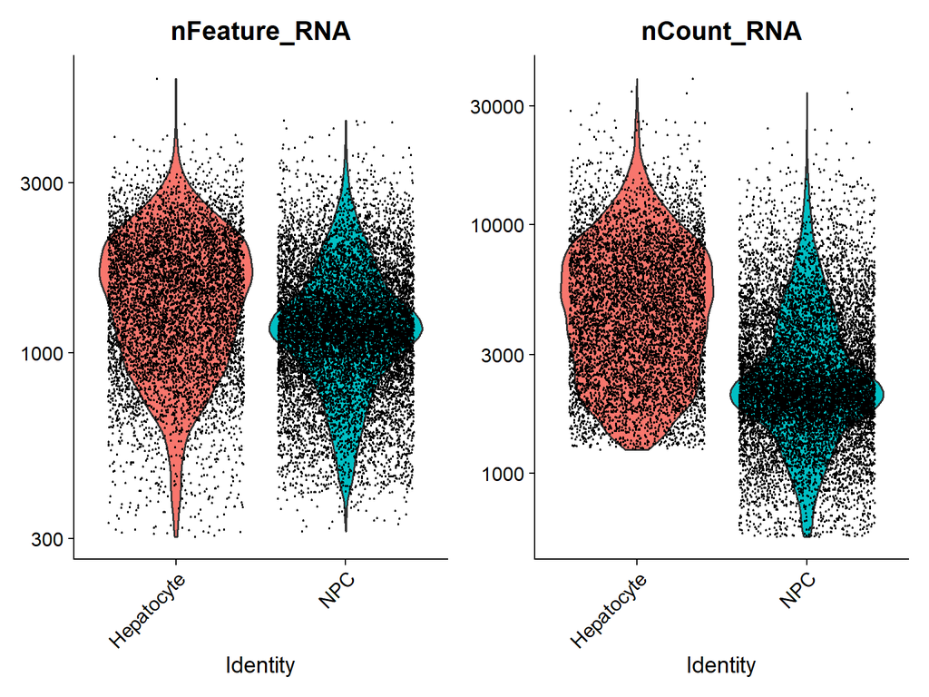

```r
# Establish the default assay
DefaultAssay(sce) <- 'RNA'

# Add column for the percentage of reads associated with mitochondrial genes - Not found in our dataset

#sce = PercentageFeatureSet(sce, col.name = "percent.mt", assay = "RNA", pattern = "^mt-")

# Check the plot for features, counts & percentage of mitochondrial genes
VlnPlot(sce, features = c("nFeature_RNA", "nCount_RNA"), ncol = 2,log=T)
```

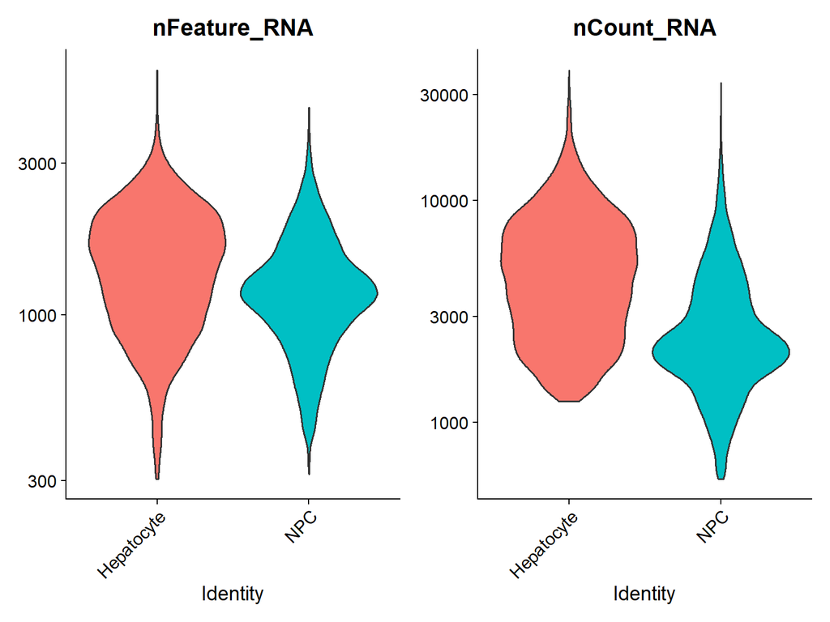

```r
VlnPlot(sce, features = c("nFeature_RNA", "nCount_RNA"), ncol = 2,log=T,pt.size = 0)
```

We could not find any mitochondrial genes in the dataset (based on the `^mt-` classification). The expectation is that these genes were filtered out before the raw data was deposited online.

These violin plots are more informative in log scale (especially for the lower cutoffs). Looking at the `nCount_RNA`, we can also observe that there was already some pre-filtering performed in this dataset. For this, we also observe less sequencing depth in NPC’s compared with hepatocytes, which is a good indication that cut-offs should be performed per sorted cell type.

We have two batch variables, ‘Animal’ and ‘Capture’. Considering the pre-processing should be done on a *per sample* level (if not in multiplex), let us check if these variables have any influence in the filtering, we should perform violin plots according with these variables:

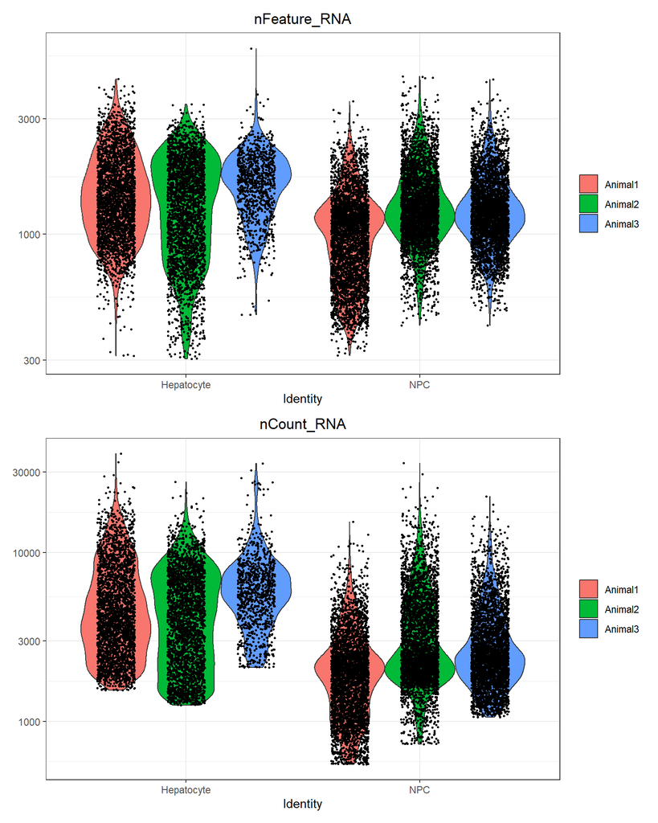

```r
f1 = VlnPlot(sce, features = c("nFeature_RNA"), log=T,group.by = "sort",split.by = "animal",pt.size = 0.5)+scale_fill_hue()+
  theme_bw()+
  theme(plot.title=element_text(hjust = 0.5))

f2 = VlnPlot(sce, features = c("nCount_RNA"), log=T,group.by = "sort",split.by = "animal",pt.size=0.5)+scale_fill_hue()+
  theme_bw()+
  theme(plot.title=element_text(hjust = 0.5))

f1 + f2
```

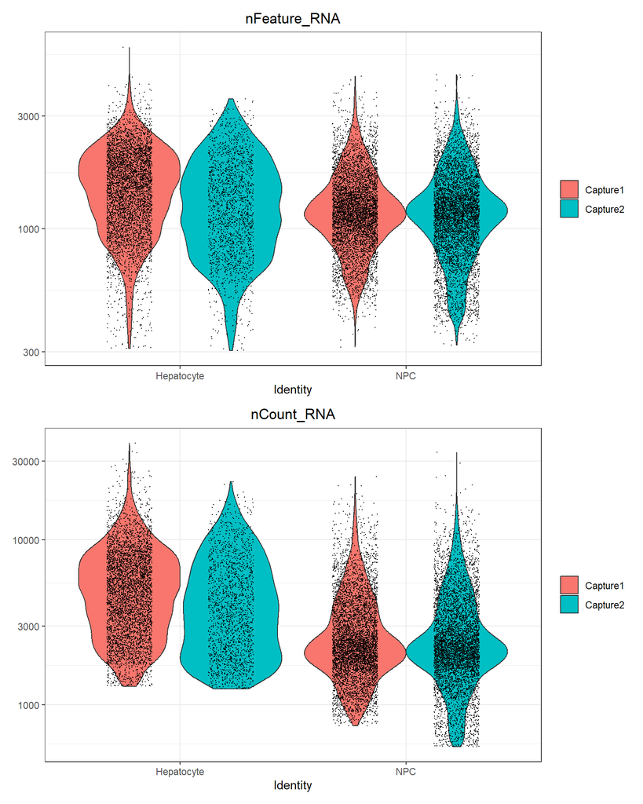

```r
#####################################################################################################################

f3 = VlnPlot(sce, features = c("nFeature_RNA"), log=T,group.by = "sort",split.by = "capture")+scale_fill_hue()+
  theme_bw()+
  theme(plot.title=element_text(hjust = 0.5))

f4 = VlnPlot(sce, features = c("nCount_RNA"), log=T,group.by = "sort",split.by = "capture")+scale_fill_hue()+
  theme_bw()+
  theme(plot.title=element_text(hjust = 0.5))

f3 + f4
```

For the ‘Capture’ variable, a customized approach *per capture* is not necessary; on the other hand, there seems to exist a pattern per ‘Animal’ in our dataset (in fact, we can observe already some performed filtering). Specifically for `nFeature_RNA` in hepatocytes, we can perform a more hard filtering:

- For Animal 1, hepatocytes can be filtered at 650 features;
- For Animal 2, the filtering is good,
- For Animal 3, hepatocytes can be filtered at 650 features;

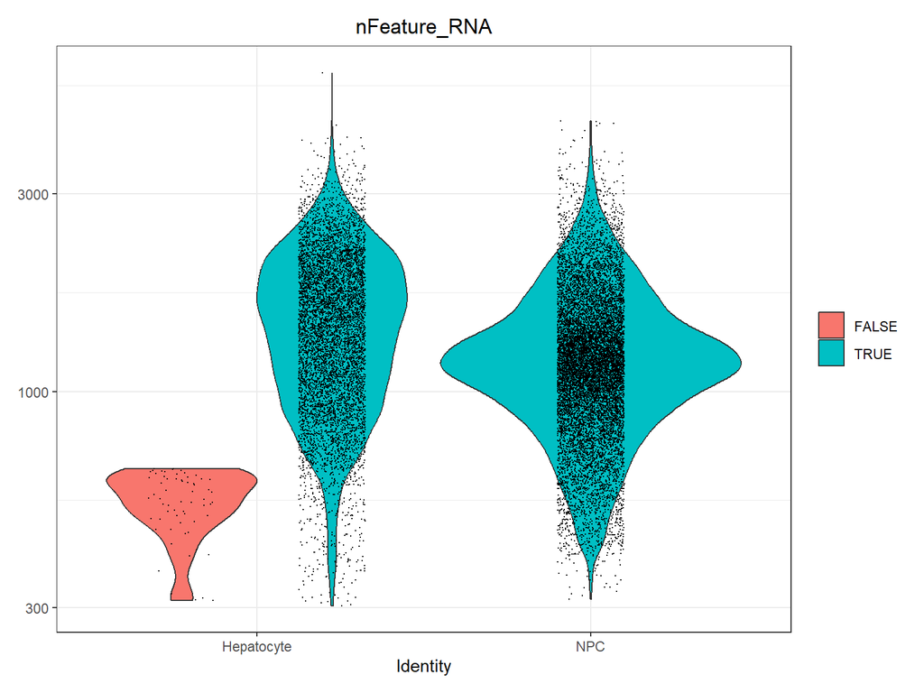

```r
metadata= metadata %>%
  mutate(QC_filt = case_when(
    sort=="NPC" ~ TRUE,
    sort=="Hepatocyte" & animal=="Animal1" & nFeature_RNA>650 ~ TRUE,
    sort=="Hepatocyte" & animal=="Animal2" ~ TRUE,
    sort=="Hepatocyte" & animal=="Animal3" & nFeature_RNA>650 ~ TRUE,
    TRUE ~ FALSE
  ))

sce$QC_filt1 = metadata$QC_filt

VlnPlot(sce, features = c("nFeature_RNA"), log=T,group.by = "sort",split.by = "QC_filt1")+scale_fill_hue()+
  theme_bw()+
  theme(plot.title=element_text(hjust = 0.5))
```

```r
sce_qcfilt = subset(sce, subset=QC_filt1)



cat(paste0(bold("\nNumber of cells kept: "), ncol(sce_qcfilt@assays$RNA)," (",
           ncol(sce@assays$RNA) - ncol(sce_qcfilt@assays$RNA)," cells excluded)"))
```

```
Number of cells kept: 18924 (63 cells excluded)
```

In total, we only discarded additional **63** cells - a small number like this was expected, considered the dataset had been previously filtered.

### Normalization

In the normalization step, we are going to perform `sctransform`. As stated in the paper, it is possible to use this function to account for batch effects - in our case, ‘animal’ and ‘capture’; however, this approach is not fully consensusal - There is some discussing on how useful is this (https://github.com/satijalab/seurat/issues/7866) and if we should do this normalization step *per sample*.

#### `sctransform` on full dataset

According with `sctransform` paper, we have to perform two rounds of normalization - first, to account for library size, and only afterwards the batch effect.

```r
cat("\nRunning the first normalization step - with just per-sample metrics\n")
```

```
Running the first normalization step - with just per-sample metrics
```

```r
sce_norm1 = SCTransform(sce_qcfilt, verbose = F,
                        vars.to.regress = c("nFeature_RNA", "nCount_RNA"),
                        variable.features.n = 5000,
                        seed.use = 123)

DefaultAssay(sce_norm1) = "SCT"

cat("\nRunning the second normalization step - with per-sample metrics and batch effect\n")
```

```
Running the second normalization step - with per-sample metrics and batch effect
```

```r
sce_norm2 = SCTransform(sce_norm1, verbose = F,
                        vars.to.regress = c("nFeature_RNA", "nCount_RNA","animal","capture"),
                        variable.features.n = 5000,
                        seed.use = 123)
```

## Dimensionality Reduction

### Principal Component Analysis (PCA)

First step is to determine the number of principal components (PCs) that should be included for UMAPs

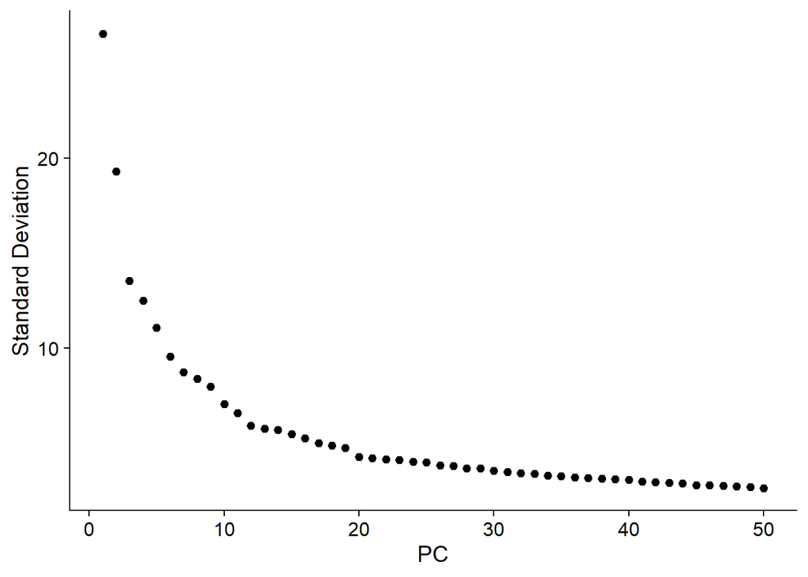

```r
sce_pca = RunPCA(sce_norm2, verbose = T, assay = "SCT", npcs = 50)

#DimPlot(sce_pca, reduction = "pca", dims = 1:2)

ElbowPlot(sce_pca, ndims = 50)
```

Probably, we are safe to use only 30 PC’s for the UMAP.

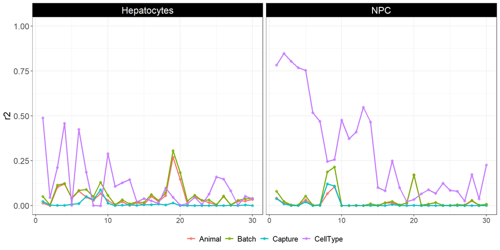

```r
PCA_df = sce_pca@reductions$pca@cell.embeddings %>%
  as.data.frame() %>% mutate(UniqueID = rownames(.))

res_PCA = data.frame(PC=NA,sort=NA,cond=NA,r2=NA)

for (i in 1:30){

  tb = data.frame(sce_pca@meta.data, PC = PCA_df[,i]) %>%
    mutate(batch=paste0(animal,"_",capture))

  tb_list = split(tb,tb$sort)

  m1_hep = lm(PC ~ animal,data=tb_list$Hepatocyte)
  m2_hep = lm(PC ~ capture,data=tb_list$Hepatocyte)
  m3_hep = lm(PC ~ batch,data=tb_list$Hepatocyte)
  m4_hep = lm(PC ~ celltype,data=tb_list$Hepatocyte)

  m1_NPC = lm(PC ~ animal,data=tb_list$NPC)
  m2_NPC = lm(PC ~ capture,data=tb_list$NPC)
  m3_NPC = lm(PC ~ batch,data=tb_list$NPC)
  m4_NPC = lm(PC ~ celltype,data=tb_list$NPC)

  temp = data.frame(PC=i,
                    sort=rep(c("Hepatocytes","NPC"),each=4),
                    cond=rep(c("Animal","Capture","Batch","CellType"),times=2),
                    r2 = c(performance::r2(m1_hep)$R2_adjusted,performance::r2(m2_hep)$R2_adjusted,performance::r2(m3_hep)$R2_adjusted,
                           performance::r2(m4_hep)$R2_adjusted,
                           performance::r2(m1_NPC)$R2_adjusted,performance::r2(m2_NPC)$R2_adjusted,performance::r2(m3_NPC)$R2_adjusted,
                           performance::r2(m4_NPC)$R2_adjusted))
  res_PCA = rbind(res_PCA,temp)

}

res_PCA %>%
  filter(!is.na(PC)) %>%
  ggplot(.,aes(x=PC,y=r2,color=cond))+
    geom_point(size=2,alpha=.7)+
    geom_line(aes(group=cond),linewidth=1)+
    facet_wrap(~sort,nrow=1)+
    theme_bw()+
    ylim(min(res_PCA$PC),1)+
    theme(axis.title.x=element_blank(),axis.text = element_text(size=12),
        plot.title = element_text(hjust=0.5),strip.background=element_rect(fill="black"),
        strip.text = element_text(color="white",size=16),
        legend.position = "bottom",text = element_text(size=16),legend.title=element_blank(),axis.text.y=element_text(size=14))
```

Looking at the results: - The biggest R2 values are definitely for the CellType, which makes sense. Interestingly, this variable seems to be more relevant for NPCs; - There are some effects in early PC’s with some relevant R2 for animal (in hepatocytes) and for Capture (in NPCs)

This could be an indications we should perform some kind of batch correction (via integration).

### UMAP

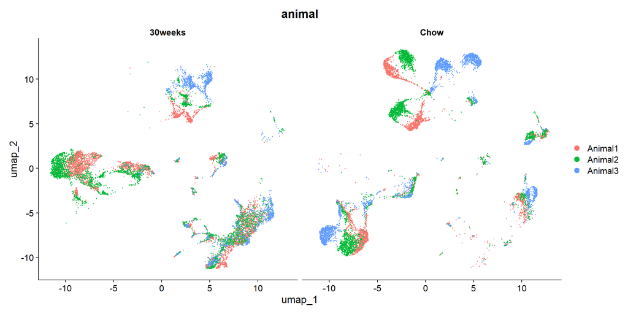

```r
sce_umap <- RunUMAP(sce_pca, dims = 1:30, verbose = F)

sce_umap@meta.data =
    sce_umap@meta.data %>%
        mutate(batch=paste0(animal,"_",capture))


DimPlot(sce_umap, reduction = "umap",group.by = "animal",split.by = "time")
```

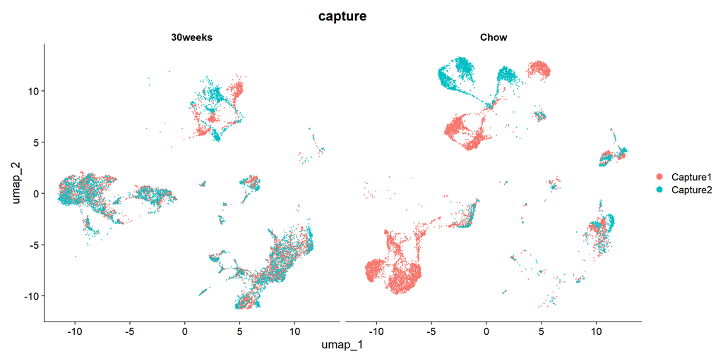

```r
DimPlot(sce_umap, reduction = "umap",group.by = "capture",split.by = "time")
```

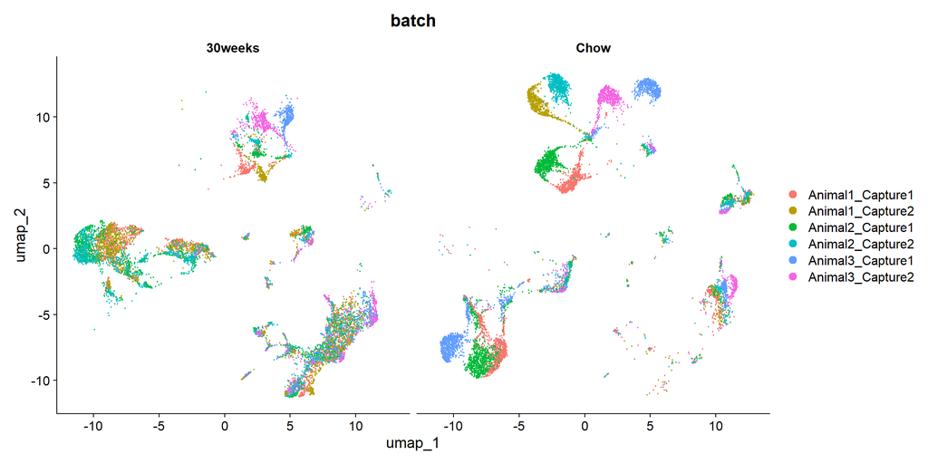

```r
DimPlot(sce_umap, reduction = "umap",group.by = "batch",split.by = "time")
```

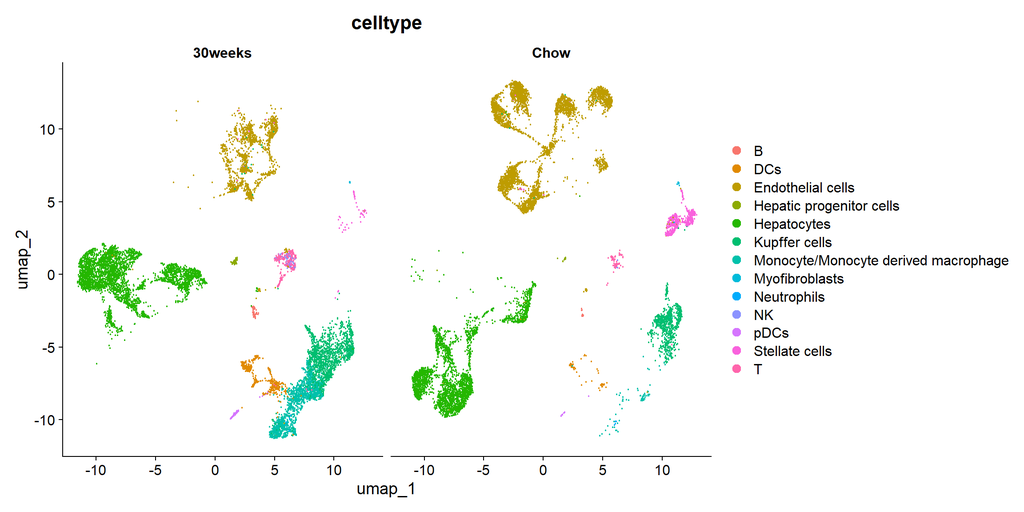

```r
DimPlot(sce_umap, reduction = "umap",group.by = "celltype",split.by = "time")
```

The UMAPs produced showed us: - Cell types seem pretty well defined, as expected; - There are some rotations & clusters that seem associated with capture (mostly for hepatocytes and endothelial cells). This is an indication that we should perform some integration & batch correction in our dataset, taking ‘capture’ into consideration.

For the sake of time, we are going to filter our dataset only for ‘Capture1’.

## Filtering for ‘Capture1’

```r
sce_filt = subset(sce_qcfilt,subset=capture=="Capture1")

sce = sce_filt

sce_filt
```

```
An object of class Seurat
25127 features across 10954 samples within 1 assay
Active assay: RNA (25127 features, 0 variable features)
 1 layer present: counts
```

```r
#################

metadata = sce@meta.data

table(metadata$animal,metadata$sort,metadata$time)
```

```
, ,  = 30weeks


          Hepatocyte  NPC
  Animal1        988 1000
  Animal2        987 1000
  Animal3          0 1000

, ,  = Chow


          Hepatocyte  NPC
  Animal1        985 1000
  Animal2       1000 1000
  Animal3        994 1000
```

```r
table(metadata$capture,metadata$sort,metadata$time)
```

```
, ,  = 30weeks


           Hepatocyte  NPC
  Capture1       1975 3000

, ,  = Chow


           Hepatocyte  NPC
  Capture1       2979 3000
```

```r
cat(paste0(bold("\nTotal Number of Genes with >0 counts: "), sum(rowSums(sce@assays$RNA) > 0)," (",
           round(100*sum(rowSums(sce@assays$RNA) > 0) / nrow(sce@assays$RNA),2),"% of full dataset)"))
```

```
Total Number of Genes with >0 counts: 17028 (67.77% of full dataset)
```

We get only ~11k samples now, with ~17K genes with >0 counts (~68% of the dataset).

```r
sce_norm = SCTransform(sce, verbose = F,
                        vars.to.regress = c("nFeature_RNA", "nCount_RNA"),
                        variable.features.n = 5000,
                        seed.use = 123)

saveRDS(sce_norm,"Capt_norm_sce.RDS")

rm(list=ls())

sce = readRDS("Capt_norm_sce.RDS")
```

## Dimensionality Reduction - Only Capture1

### Principal Component Analysis (PCA)

First step is to determine the number of principal components (PCs) that should be included for UMAPs

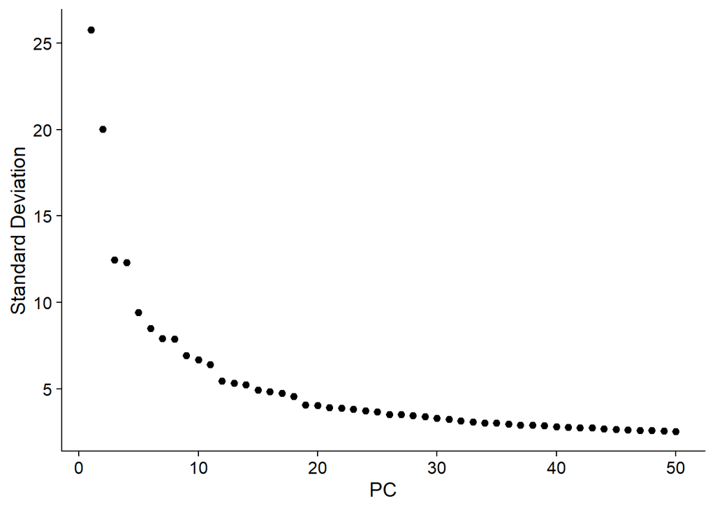

```r
sce_pca = RunPCA(sce, verbose = T, assay = "SCT", npcs = 50)

#DimPlot(sce_pca, reduction = "pca", dims = 1:2)

ElbowPlot(sce_pca, ndims = 50)
```

We are keeping the number of PC’s at 40 - to be a bit more permissive.

### UMAP

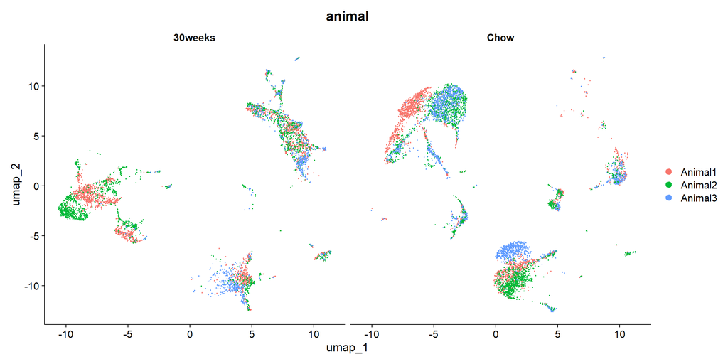

```r
sce_umap <- RunUMAP(sce_pca, dims = 1:40, verbose = F)

sce_umap@meta.data =
    sce_umap@meta.data %>%
        mutate(batch=paste0(animal,"_",capture))


DimPlot(sce_umap, reduction = "umap",group.by = "animal",split.by = "time")
```

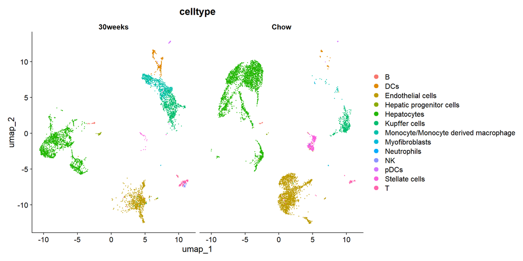

```r
DimPlot(sce_umap, reduction = "umap",group.by = "celltype",split.by = "time")
```

Although the integration is not perfect, we consider it is safe to proceed with the analysis.

We are going to check the UMAP, divided by cell type:

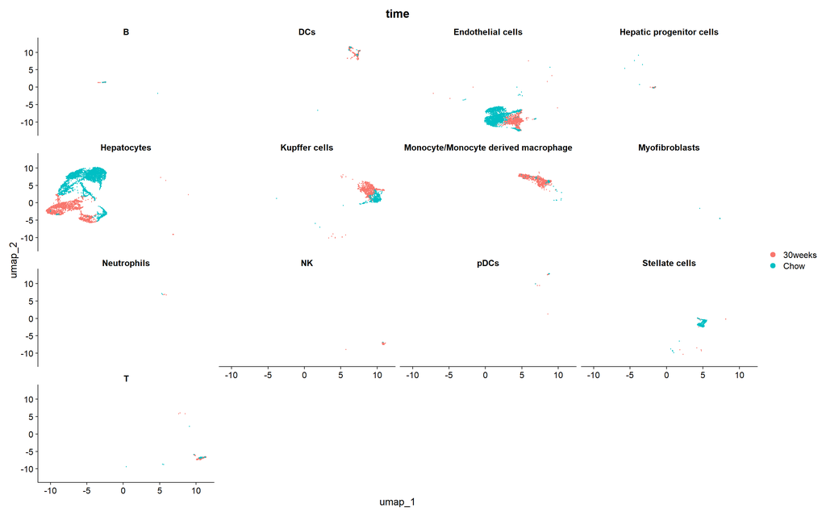

```r
DimPlot(sce_umap, reduction = "umap",group.by = "time",split.by = "celltype",ncol = 4)
```

## Downstream Analysis

### Gene Set Enrichment Analysis

```r
table(sce$time,sce$celltype)
```

```
             B  DCs Endothelial cells Hepatic progenitor cells Hepatocytes
  30weeks   30  235               855                       48        1921
  Chow      11   28              2001                       10        3094

          Kupffer cells Monocyte/Monocyte derived macrophage Myofibroblasts
  30weeks           820                                  795              5
  Chow              433                                   39             10

          Neutrophils   NK pDCs Stellate cells    T
  30weeks           3   31   50             29  153
  Chow              2    1    8            302   40
```

From the data here, we see that the number of cells is considerably reduced in several conditions. For those which have =<5 in one of the groups, we will not considered it.

```r
Idents(sce) = sce$time

cells_df = table(sce$time,sce$celltype) %>% as.data.frame() %>% group_by(Var2) %>% summarise(keep=all(Freq>5))

comp_l = cells_df$Var2[cells_df$keep==T]

de_cond_l = list()

for(n in comp_l){

  cat(paste0("\nTaking care of: ",n," - diff. analysis\n"))
    cells = sce$celltype %in% n
    print(table(sce[,cells]$celltype, sce[,cells]$time))

    de_cond_l[[n]] = FindMarkers(sce[,cells], ident.1 = "30weeks", ident.2 = "Chow")
}
```

```
Taking care of: B - diff. analysis

    30weeks Chow
  B      30   11

Taking care of: DCs - diff. analysis

      30weeks Chow
  DCs     235   28

Taking care of: Endothelial cells - diff. analysis

                    30weeks Chow
  Endothelial cells     855 2001

Taking care of: Hepatic progenitor cells - diff. analysis

                           30weeks Chow
  Hepatic progenitor cells      48   10

Taking care of: Hepatocytes - diff. analysis

              30weeks Chow
  Hepatocytes    1921 3094

Taking care of: Kupffer cells - diff. analysis

                30weeks Chow
  Kupffer cells     820  433

Taking care of: Monocyte/Monocyte derived macrophage - diff. analysis

                                       30weeks Chow
  Monocyte/Monocyte derived macrophage     795   39

Taking care of: pDCs - diff. analysis

       30weeks Chow
  pDCs      50    8

Taking care of: Stellate cells - diff. analysis

                 30weeks Chow
  Stellate cells      29  302

Taking care of: T - diff. analysis

    30weeks Chow
  T     153   40
```

```r
allgenes = rownames(sce) # all genes, to serve as background

res_GSEA = data.frame(comp=NA,term_name=NA,intersection_size=NA,p_value=NA)

for (n in names(de_cond_l)) {

    cat(paste0("\nTaking care of: ",n," - GSEA\n"))

  mk_clusters = de_cond_l[[n]]

  degenes = mk_clusters %>%
    arrange(-avg_log2FC)

  cat(paste0("\n -> Up-regulated"))

  gprof_up = gost(rownames(degenes), ordered_query = T,
                custom_bg = allgenes, # always set a custom bg!
                sources = "GO:BP",
                correction_method = "g_SCS", # more stringent than FDR,
                organism = "mmusculus", user_threshold = 0.05)

  degenes = mk_clusters %>%
    arrange(avg_log2FC)

  cat(paste0("\n -> Down-regulated"))

  gprof_down = gost(rownames(degenes), ordered_query = T,
                custom_bg = allgenes, # always set a custom bg!
                sources = "GO:BP",
                correction_method = "g_SCS", # more stringent than FDR,
                organism = "mmusculus", user_threshold = 0.05)

  temp = gprof_up$result %>%
    rbind(gprof_down$result %>% mutate(intersection_size=-intersection_size)) %>%
    filter(p_value<0.01) %>%
    top_n(n = 10,wt=-log10(p_value)) %>%
    mutate(comp=n) %>%
    select(comp,term_name,intersection_size,p_value)


res_GSEA = rbind(res_GSEA,temp)
}
```

```
Taking care of: B - GSEA

 -> Up-regulated
```

```
 -> Down-regulated
```

```
Taking care of: DCs - GSEA

 -> Up-regulated
```

```
 -> Down-regulated
```

```
Taking care of: Endothelial cells - GSEA

 -> Up-regulated
```

```
 -> Down-regulated
```

```
Taking care of: Hepatic progenitor cells - GSEA

 -> Up-regulated
```

```
 -> Down-regulated
```

```
Taking care of: Hepatocytes - GSEA

 -> Up-regulated
```

```
 -> Down-regulated
```

```
Taking care of: Kupffer cells - GSEA

 -> Up-regulated
```

```
 -> Down-regulated
```

```
Taking care of: Monocyte/Monocyte derived macrophage - GSEA

 -> Up-regulated
```

```
 -> Down-regulated
```

```
Taking care of: pDCs - GSEA

 -> Up-regulated
```

```
 -> Down-regulated
```

```
Taking care of: Stellate cells - GSEA

 -> Up-regulated
```

```
 -> Down-regulated
```

```
Taking care of: T - GSEA

 -> Up-regulated
```

```
 -> Down-regulated
```

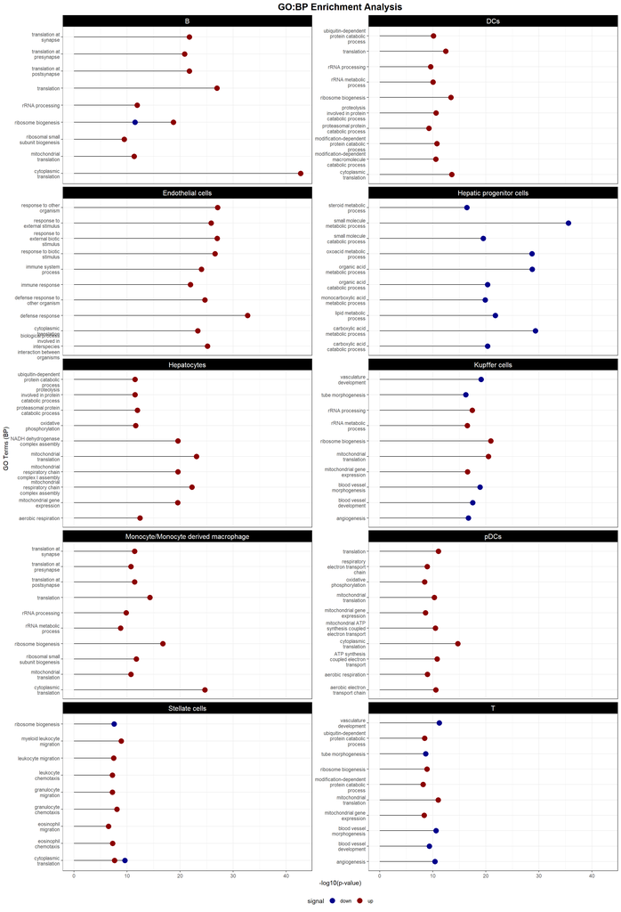

```r
res_GSEA %>%
  mutate(signal=ifelse(intersection_size<0,"down","up")) %>%
  filter(!is.na(comp)) %>%
  ggplot(aes(x=-log10(p_value),y=term_name,color=signal))+
    geom_segment(aes(x = 0, xend =-log10(p_value), y = term_name,yend=term_name),
                 color = "black")+
    geom_point(size = 4)+
    scale_colour_manual(values = c("down"="darkblue","up"="darkred"))+
    facet_wrap(~comp,ncol=2,scales="free_y")+
    scale_y_discrete(labels = scales::label_wrap(20)) +
    theme_bw()+
    labs(title = "GO:BP Enrichment Analysis")+
    xlab("-log10(p-value)")+
    ylab("GO Terms (BP)")+
    theme(strip.background=element_rect(fill="black"),
          strip.text = element_text(color="white",size=12),
          plot.title = element_text(size=16,hjust=0.5,face="bold"),
          plot.subtitle = element_text(size=12,hjust=0.5,face="italic"),
          legend.position="bottom")
```

### Cell-Cell Communication

```r
srat_n = sce[,sce$time=="Chow"]
srat_t = sce[,sce$time=="30weeks"]

cat(paste0("\nProcessing Chow cells\n"))
```

```
Processing Chow cells
```

```r
cell_tab = table(srat_n$celltype)
cells_keep = colnames(srat_n)[srat_n$celltype %in% names(cell_tab)[cell_tab>=10]]
srat_n = srat_n[,cells_keep]
print(sort(unique(srat_n$celltype)))
```

```
 [1] "B"
 [2] "DCs"
 [3] "Endothelial cells"
 [4] "Hepatic progenitor cells"
 [5] "Hepatocytes"
 [6] "Kupffer cells"
 [7] "Monocyte/Monocyte derived macrophage"
 [8] "Myofibroblasts"
 [9] "Stellate cells"
[10] "T"
```

```r
cat(paste0("\nProcessing 30weeks cells\n"))
```

```
Processing 30weeks cells
```

```r
cell_tab = table(srat_t$celltype)
cells_keep = colnames(srat_t)[srat_t$celltype %in% names(cell_tab)[cell_tab>=10]]
srat_t = srat_t[,cells_keep]
print(sort(unique(srat_t$celltype)))
```

```
 [1] "B"
 [2] "DCs"
 [3] "Endothelial cells"
 [4] "Hepatic progenitor cells"
 [5] "Hepatocytes"
 [6] "Kupffer cells"
 [7] "Monocyte/Monocyte derived macrophage"
 [8] "NK"
 [9] "pDCs"
[10] "Stellate cells"
[11] "T"
```

```r
cat(bold(paste0("\nDifferences between cell types in conditions\n")))
```

```
Differences between cell types in conditions
```

```r
cat(paste0("\n-> Only for Chow: ",unique(srat_n$celltype)[!unique(srat_n$celltype) %in% srat_t$celltype]))
```

```
-> Only for Chow: Myofibroblasts
```

```r
cat(paste0("\n-> Only for 30weeks: ", as.character(paste0(unique(srat_t$celltype)[!unique(srat_t$celltype) %in% srat_n$celltype],collapse=", "))))
```

```
-> Only for 30weeks: pDCs, NK
```

We have cells that are specific for each time-point/condition. To make the comparisons more comparable, let’s exclude the cell types not overlapping.

```r
overlap = intersect(unique(srat_n$celltype),unique(srat_t$celltype))

cat(paste0("\nProcessing Chow cells\n"))
```

```
Processing Chow cells
```

```r
cells_keep = colnames(srat_n)[srat_n$celltype %in% overlap]
srat_n = srat_n[,cells_keep]
print(sort(unique(srat_n$celltype)))
```

```
[1] "B"
[2] "DCs"
[3] "Endothelial cells"
[4] "Hepatic progenitor cells"
[5] "Hepatocytes"
[6] "Kupffer cells"
[7] "Monocyte/Monocyte derived macrophage"
[8] "Stellate cells"
[9] "T"
```

```r
cat(paste0("\nProcessing 30weeks cells\n"))
```

```
Processing 30weeks cells
```

```r
cell_tab = table(srat_t$celltype)
cells_keep = colnames(srat_t)[srat_t$celltype %in% overlap]
srat_t = srat_t[,cells_keep]
print(sort(unique(srat_t$celltype)))
```

```
[1] "B"
[2] "DCs"
[3] "Endothelial cells"
[4] "Hepatic progenitor cells"
[5] "Hepatocytes"
[6] "Kupffer cells"
[7] "Monocyte/Monocyte derived macrophage"
[8] "Stellate cells"
[9] "T"
```

Now, we will proceed to LIANA

```r
liana_n = liana_wrap(srat_n, idents_col = "celltype",
                     method = "cellphonedb", resource = c("MouseConsensus"),
                     permutation.params = list(nperms=500, parallelize=F, workers=4)) # you may need to adjust these depending on your computer
liana_t = liana_wrap(srat_t, idents_col = "celltype",
                     method = "cellphonedb", resource = c("MouseConsensus"),
                     permutation.params = list(nperms=500, parallelize=F, workers=4)) # you may need to adjust these depending on your computer
```

**Normal Conditions (Chow)**

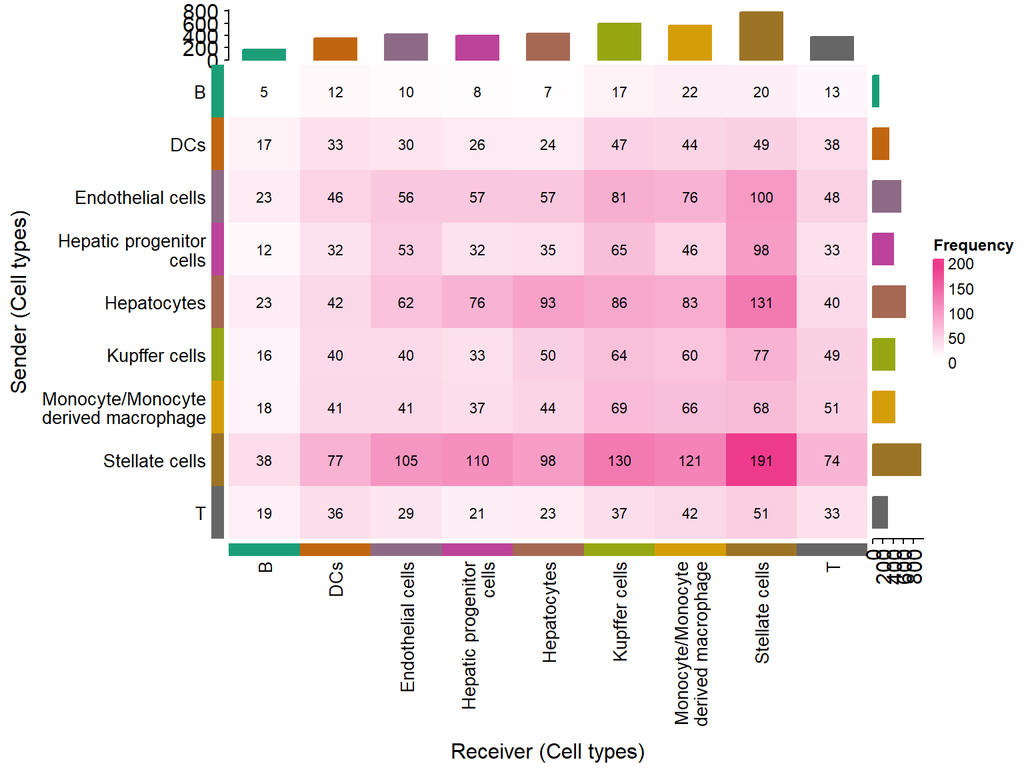

```r
liana_n_filt = liana_n[liana_n$pvalue<=0.01,]
liana_t_filt = liana_t[liana_t$pvalue<=0.01,]

q20lr = quantile(c(liana_n_filt$lr.mean, liana_t_filt$lr.mean), 0.20)
liana_n_filt = liana_n_filt[liana_n_filt$lr.mean>q20lr,]
liana_t_filt = liana_t_filt[liana_t_filt$lr.mean>q20lr,]

liana_n_filt_wrapped <- liana_n_filt %>%
  mutate(
    source = str_wrap(source, width = 20),
    target = str_wrap(target, width = 20)
  )


heat_freq(liana_n_filt_wrapped, grid_text=T, font_size = 10)
```

**30 weeks**

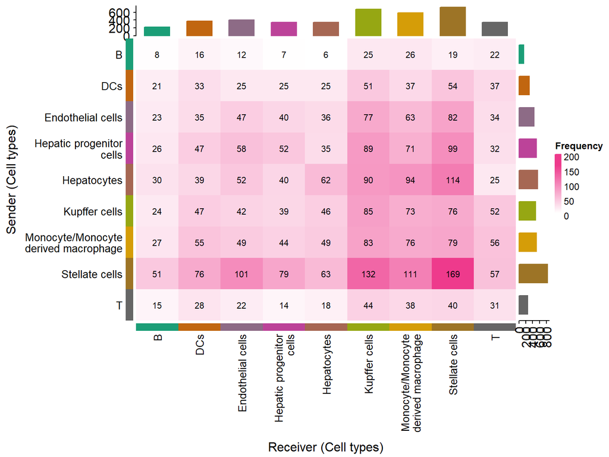

```r
#################################################################

liana_t_filt_wrapped <- liana_t_filt %>%
  mutate(
    source = str_wrap(source, width = 20),
    target = str_wrap(target, width = 20)
  )


heat_freq(liana_t_filt_wrapped, grid_text=T, font_size = 10)
```

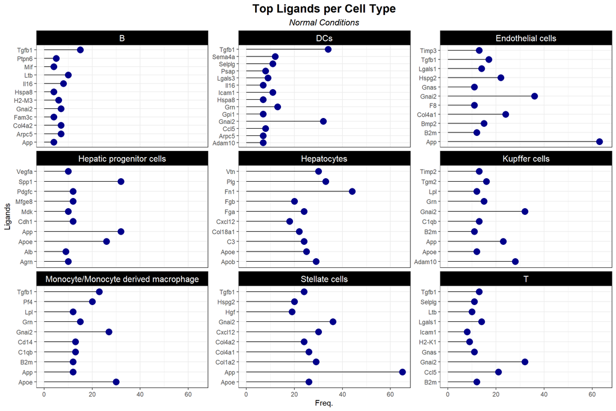

```r
liana_n_filt %>%
  group_by(source,ligand) %>%
  summarise(Freq=n()) %>%
  top_n(n = 10,Freq) %>%
  ggplot(aes(x=Freq,y=ligand))+
    geom_segment(aes(x = 0, xend =Freq, y = ligand,yend=ligand),
                 color = "black")+
    geom_point(size = 4,color="darkblue")+
    facet_wrap(~source,scales="free_y")+
    theme_bw()+
    labs(title = "Top Ligands per Cell Type",subtitle = "Normal Conditions")+
    xlab("Freq.")+
    ylab("Ligands")+
    theme(strip.background=element_rect(fill="black"),
          strip.text = element_text(color="white",size=12),
          plot.title = element_text(size=16,hjust=0.5,face="bold"),
          plot.subtitle = element_text(size=12,hjust=0.5,face="italic"),
          legend.position="bottom")
```

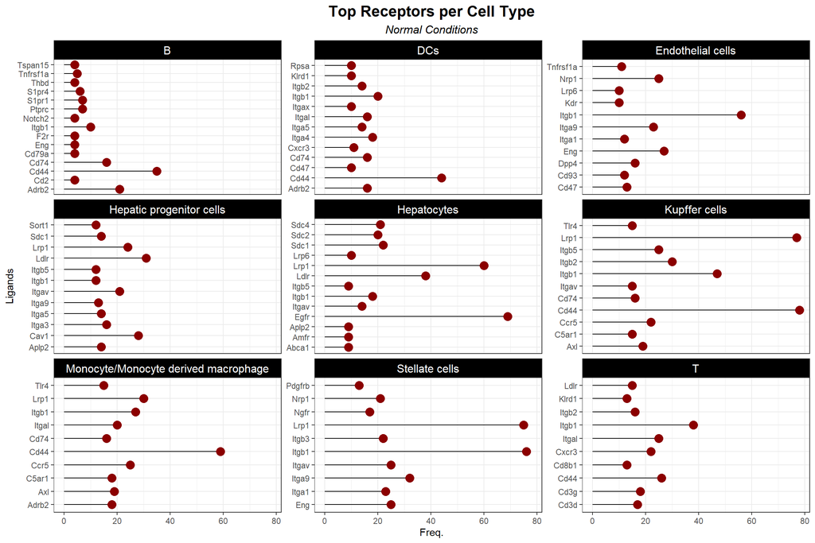

```r
liana_n_filt %>%
  group_by(target,receptor) %>%
  summarise(Freq=n()) %>%
  top_n(n = 10,Freq) %>%
  ggplot(aes(x=Freq,y=receptor))+
    geom_segment(aes(x = 0, xend =Freq, y = receptor,yend=receptor),
                 color = "black")+
    geom_point(size = 4,color="darkred")+
    facet_wrap(~target,scales="free_y")+
    theme_bw()+
    labs(title = "Top Receptors per Cell Type",subtitle = "Normal Conditions")+
    xlab("Freq.")+
    ylab("Ligands")+
    theme(strip.background=element_rect(fill="black"),
          strip.text = element_text(color="white",size=12),
          plot.title = element_text(size=16,hjust=0.5,face="bold"),
          plot.subtitle = element_text(size=12,hjust=0.5,face="italic"),
          legend.position="bottom")
```

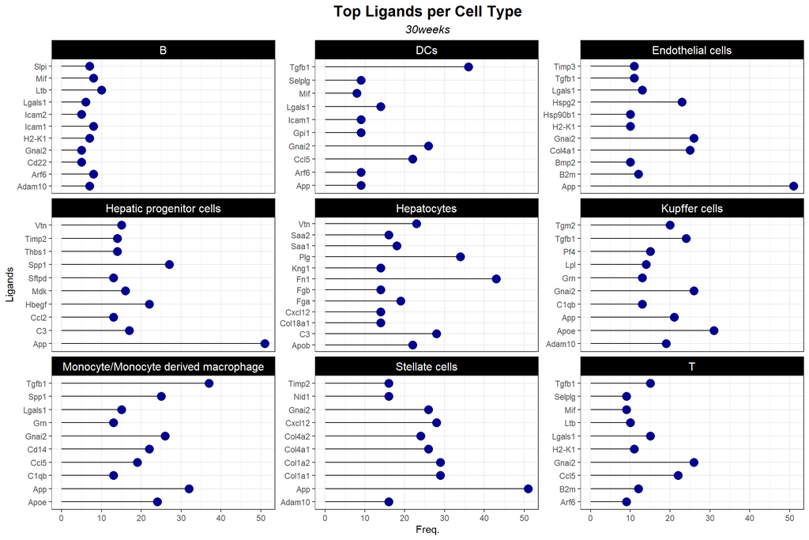

```r
liana_t_filt %>%
  group_by(source,ligand) %>%
  summarise(Freq=n()) %>%
  top_n(n = 10,Freq) %>%
  ggplot(aes(x=Freq,y=ligand))+
    geom_segment(aes(x = 0, xend =Freq, y = ligand,yend=ligand),
                 color = "black")+
    geom_point(size = 4,color="darkblue")+
    facet_wrap(~source,scales="free_y")+
    theme_bw()+
    labs(title = "Top Ligands per Cell Type",subtitle = "30weeks")+
    xlab("Freq.")+
    ylab("Ligands")+
    theme(strip.background=element_rect(fill="black"),
          strip.text = element_text(color="white",size=12),
          plot.title = element_text(size=16,hjust=0.5,face="bold"),
          plot.subtitle = element_text(size=12,hjust=0.5,face="italic"),
          legend.position="bottom")
```

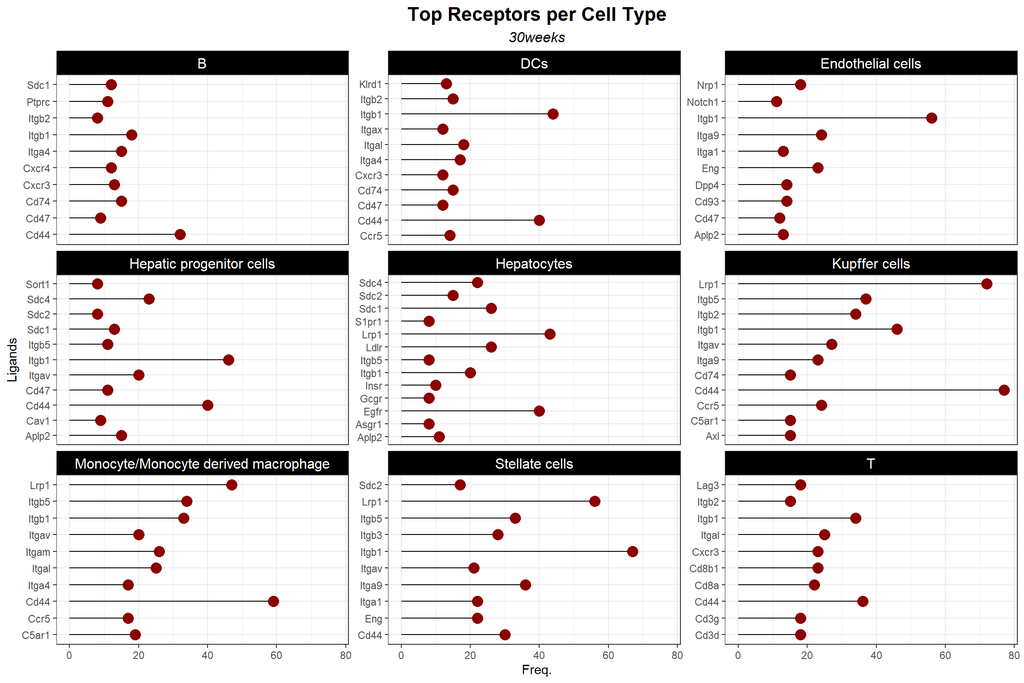

```r
liana_t_filt %>%
  group_by(target,receptor) %>%
  summarise(Freq=n()) %>%
  top_n(n = 10,Freq) %>%
  ggplot(aes(x=Freq,y=receptor))+
    geom_segment(aes(x = 0, xend =Freq, y = receptor,yend=receptor),
                 color = "black")+
    geom_point(size = 4,color="darkred")+
    facet_wrap(~target,scales="free_y")+
    theme_bw()+
    labs(title = "Top Receptors per Cell Type",subtitle = "30weeks")+
    xlab("Freq.")+
    ylab("Ligands")+
    theme(strip.background=element_rect(fill="black"),
          strip.text = element_text(color="white",size=12),
          plot.title = element_text(size=16,hjust=0.5,face="bold"),
          plot.subtitle = element_text(size=12,hjust=0.5,face="italic"),
          legend.position="bottom")
```

**Overlap**

```r
liana_n_filt = liana_n_filt %>% mutate(Comb = paste0(source,"-",ligand," to ", target," - ",receptor))
liana_t_filt = liana_t_filt %>% mutate(Comb = paste0(source,"-",ligand," to ", target," - ",receptor))

cat(paste0("Nr. of common ligand pairs: ",length(liana_n_filt$Comb[liana_n_filt$Comb %in% liana_t_filt$Comb]),
           " (",round(100*length(liana_n_filt$Comb[liana_n_filt$Comb %in% liana_t_filt$Comb])/nrow(liana_n_filt),2),"% of Normal Interactions, ",
           round(100*length(liana_n_filt$Comb[liana_n_filt$Comb %in% liana_t_filt$Comb])/nrow(liana_n_filt),2),"% of 30Weeks Interactions)"))
```

```
Nr. of common ligand pairs: 2580 (62.82% of Normal Interactions, 62.82% of 30Weeks Interactions)
```

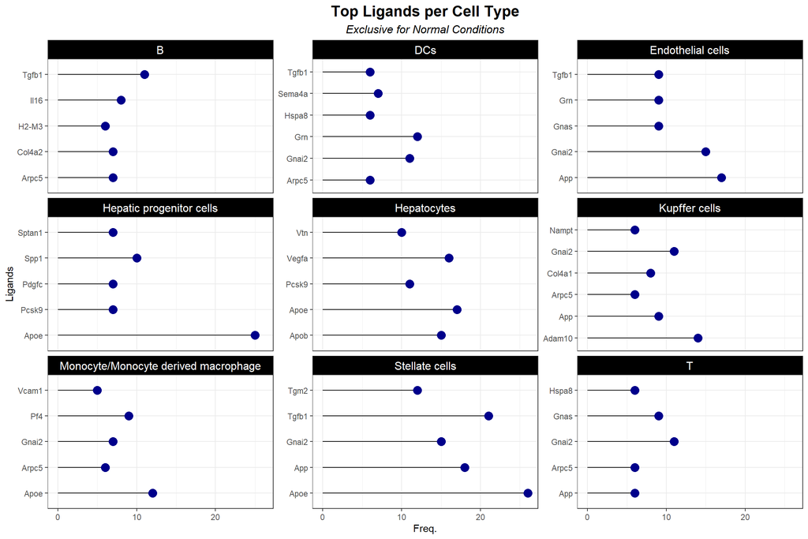

```r
liana_n_filt %>%
  filter(!Comb %in% liana_t_filt$Comb) %>%
  group_by(source,ligand) %>%
  summarise(Freq=n()) %>%
  top_n(n = 5,Freq) %>%
  ggplot(aes(x=Freq,y=ligand))+
    geom_segment(aes(x = 0, xend =Freq, y = ligand,yend=ligand),
                 color = "black")+
    geom_point(size = 4,color="darkblue")+
    facet_wrap(~source,scales="free_y")+
    theme_bw()+
    labs(title = "Top Ligands per Cell Type",subtitle = "Exclusive for Normal Conditions")+
    xlab("Freq.")+
    ylab("Ligands")+
    theme(strip.background=element_rect(fill="black"),
          strip.text = element_text(color="white",size=12),
          plot.title = element_text(size=16,hjust=0.5,face="bold"),
          plot.subtitle = element_text(size=12,hjust=0.5,face="italic"),
          legend.position="bottom")
```

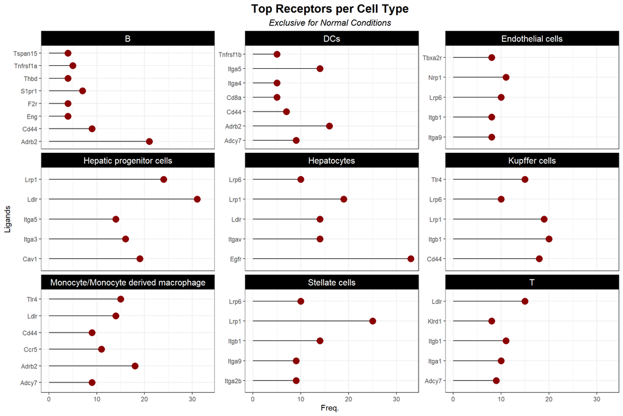

```r
liana_n_filt %>%
    filter(!Comb %in% liana_t_filt$Comb) %>%
  group_by(target,receptor) %>%
  summarise(Freq=n()) %>%
  top_n(n = 5,Freq) %>%
  ggplot(aes(x=Freq,y=receptor))+
    geom_segment(aes(x = 0, xend =Freq, y = receptor,yend=receptor),
                 color = "black")+
    geom_point(size = 4,color="darkred")+
    facet_wrap(~target,scales="free_y")+
    theme_bw()+
    labs(title = "Top Receptors per Cell Type",subtitle = "Exclusive for Normal Conditions")+
    xlab("Freq.")+
    ylab("Ligands")+
    theme(strip.background=element_rect(fill="black"),
          strip.text = element_text(color="white",size=12),
          plot.title = element_text(size=16,hjust=0.5,face="bold"),
          plot.subtitle = element_text(size=12,hjust=0.5,face="italic"),
          legend.position="bottom")
```

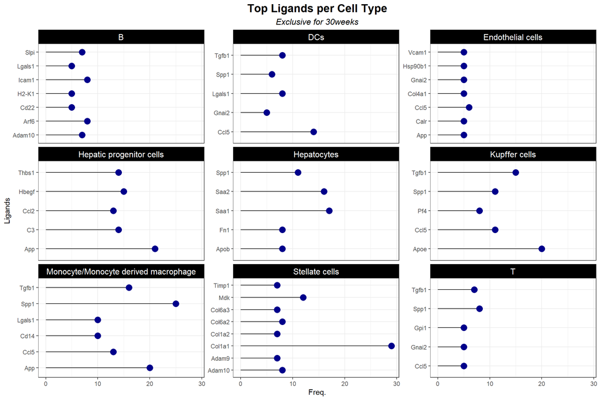

```r
####################################################################################################

liana_t_filt %>%
  filter(!Comb %in% liana_n_filt$Comb) %>%
  group_by(source,ligand) %>%
  summarise(Freq=n()) %>%
  top_n(n = 5,Freq) %>%
  ggplot(aes(x=Freq,y=ligand))+
    geom_segment(aes(x = 0, xend =Freq, y = ligand,yend=ligand),
                 color = "black")+
    geom_point(size = 4,color="darkblue")+
    facet_wrap(~source,scales="free_y")+
    theme_bw()+
    labs(title = "Top Ligands per Cell Type",subtitle = "Exclusive for 30weeks")+
    xlab("Freq.")+
    ylab("Ligands")+
    theme(strip.background=element_rect(fill="black"),
          strip.text = element_text(color="white",size=12),
          plot.title = element_text(size=16,hjust=0.5,face="bold"),
          plot.subtitle = element_text(size=12,hjust=0.5,face="italic"),
          legend.position="bottom")
```

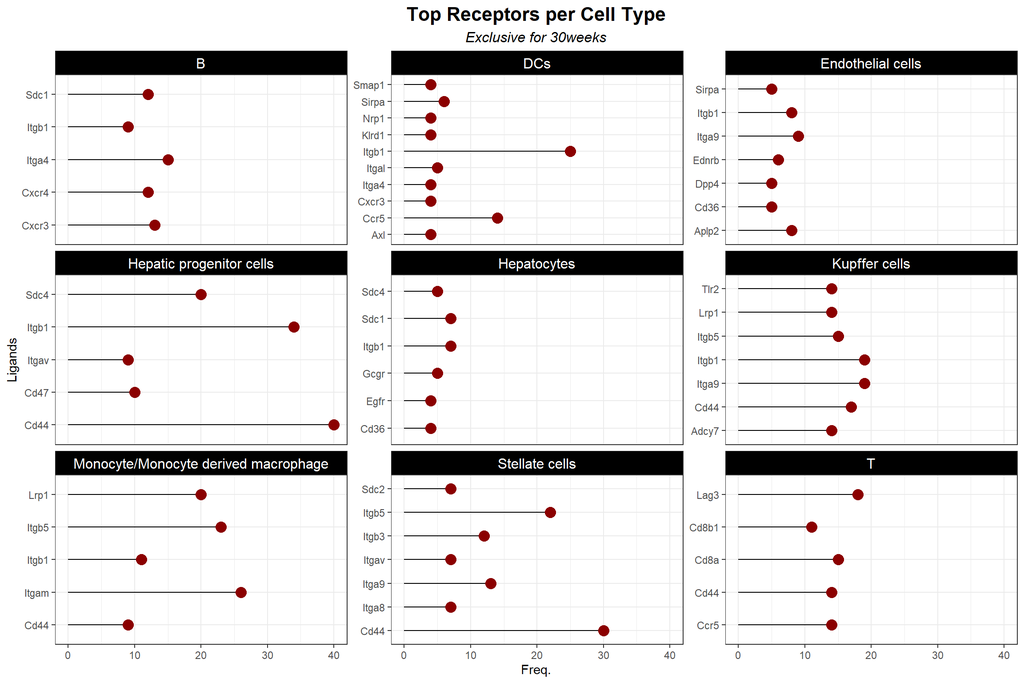

```r
liana_t_filt %>%
    filter(!Comb %in% liana_n_filt$Comb) %>%
  group_by(target,receptor) %>%
  summarise(Freq=n()) %>%
  top_n(n = 5,Freq) %>%
  ggplot(aes(x=Freq,y=receptor))+
    geom_segment(aes(x = 0, xend =Freq, y = receptor,yend=receptor),
                 color = "black")+
    geom_point(size = 4,color="darkred")+
    facet_wrap(~target,scales="free_y")+
    theme_bw()+
    labs(title = "Top Receptors per Cell Type",subtitle = "Exclusive for 30weeks")+
    xlab("Freq.")+
    ylab("Ligands")+
    theme(strip.background=element_rect(fill="black"),
          strip.text = element_text(color="white",size=12),
          plot.title = element_text(size=16,hjust=0.5,face="bold"),
          plot.subtitle = element_text(size=12,hjust=0.5,face="italic"),
          legend.position="bottom")
```

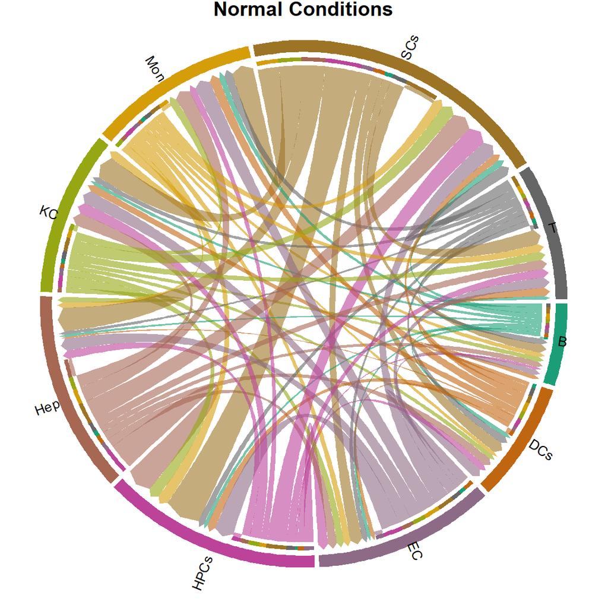

```r
liana_n_excl = liana_n_filt %>%
    filter(!Comb %in% liana_t_filt$Comb) %>%
      mutate(source=case_when(
        source=="Kupffer cells" ~ "KC",
        source=="Monocyte/Monocyte derived macrophage" ~ "Mon",
        source=="Endothelial cells" ~ "EC",
        source=="DCs" ~ "DCs",
        source=="B" ~ "B",
        source=="Stellate cells" ~ "SCs",
        source=="Hepatocytes" ~ "Hep",
        source=="T"~ "T",
        source=="Hepatic progenitor cells" ~ "HPCs",
        TRUE ~ NA
      ),target=case_when(
        target=="Kupffer cells" ~ "KC",
        target=="Monocyte/Monocyte derived macrophage" ~ "Mon",
        target=="Endothelial cells" ~ "EC",
        target=="DCs" ~ "DCs",
        target=="B" ~ "B",
        target=="Stellate cells" ~ "SCs",
        target=="Hepatocytes" ~ "Hep",
        target=="T"~ "T",
        target=="Hepatic progenitor cells" ~ "HPCs",
        TRUE ~ NA
      ))



par(cex = 0.8)  # Reduce all text to 80% of default
chord_freq(liana_n_excl)
title("Normal Conditions", cex.main = 1.5)
```

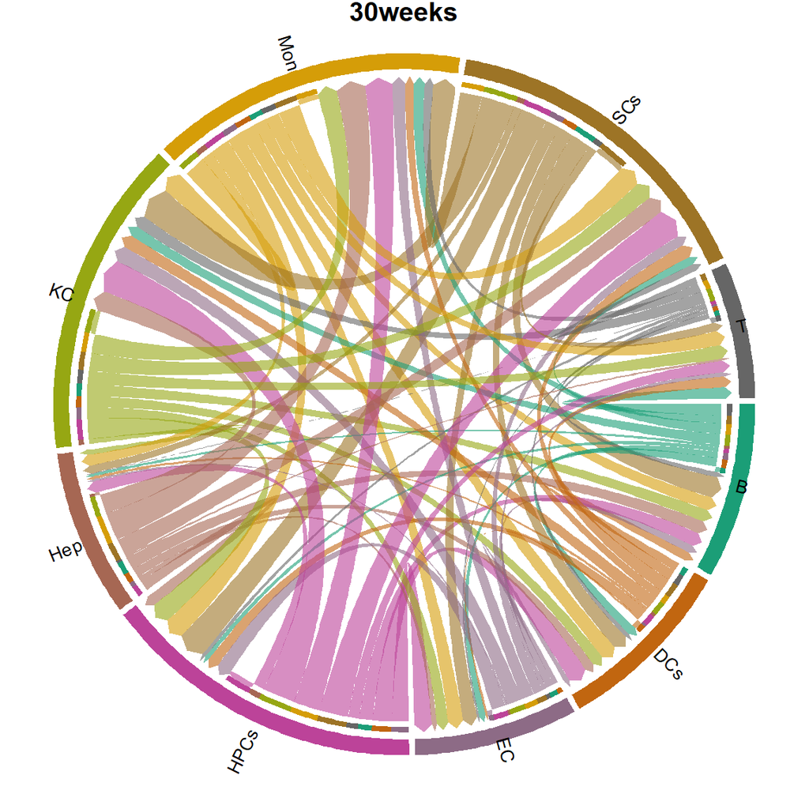

```r
###################################################################################

liana_t_excl = liana_t_filt %>%
    filter(!Comb %in% liana_n_filt$Comb) %>%
      mutate(source=case_when(
        source=="Kupffer cells" ~ "KC",
        source=="Monocyte/Monocyte derived macrophage" ~ "Mon",
        source=="Endothelial cells" ~ "EC",
        source=="DCs" ~ "DCs",
        source=="B" ~ "B",
        source=="Stellate cells" ~ "SCs",
        source=="Hepatocytes" ~ "Hep",
        source=="T"~ "T",
        source=="Hepatic progenitor cells" ~ "HPCs",
        TRUE ~ NA
      ),target=case_when(
        target=="Kupffer cells" ~ "KC",
        target=="Monocyte/Monocyte derived macrophage" ~ "Mon",
        target=="Endothelial cells" ~ "EC",
        target=="DCs" ~ "DCs",
        target=="B" ~ "B",
        target=="Stellate cells" ~ "SCs",
        target=="Hepatocytes" ~ "Hep",
        target=="T"~ "T",
        target=="Hepatic progenitor cells" ~ "HPCs",
        TRUE ~ NA
      ))



par(cex = 0.8)  # Reduce all text to 80% of default
chord_freq(liana_t_excl)
title("30weeks", cex.main = 1.5)
```

## An additional look - Olfactory Receptors

```r
sce <- PercentageFeatureSet(sce, pattern = "^Olfr", col.name = "pct_olfr",assay = "RNA")
counts <- sce@assays$RNA$counts

olfr_genes <- rownames(counts)[grepl("^Olfr", rownames(counts))]
cat(paste0("\nNr. of Olfr Genes: ",length(olfr_genes),"\n"))
```

```
Nr. of Olfr Genes: 1127
```

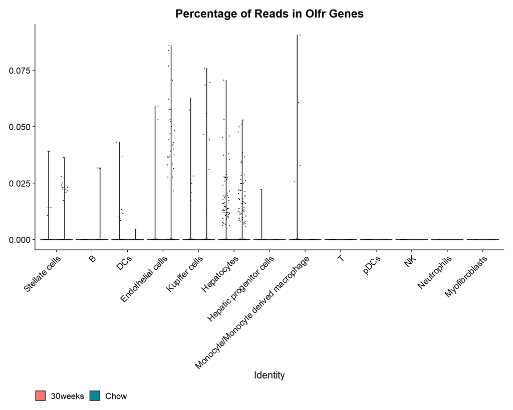

```r
VlnPlot(sce, features = c("pct_olfr"), group.by="celltype",split.by="time",sort = T)+
  ggtitle("Percentage of Reads in Olfr Genes")+
  theme(legend.position = "bottom") # these two metrics are also useful in log scale
```

```r
cat("\nNr. of Olfrs with expression per cell: \n")
```

```
Nr. of Olfrs with expression per cell:
```

```r
table(Matrix::rowSums(counts[olfr_genes, , drop = FALSE] > 0))
```

```
   0    1    3    7    8   17   23  116
1113    6    1    2    2    1    1    1
```

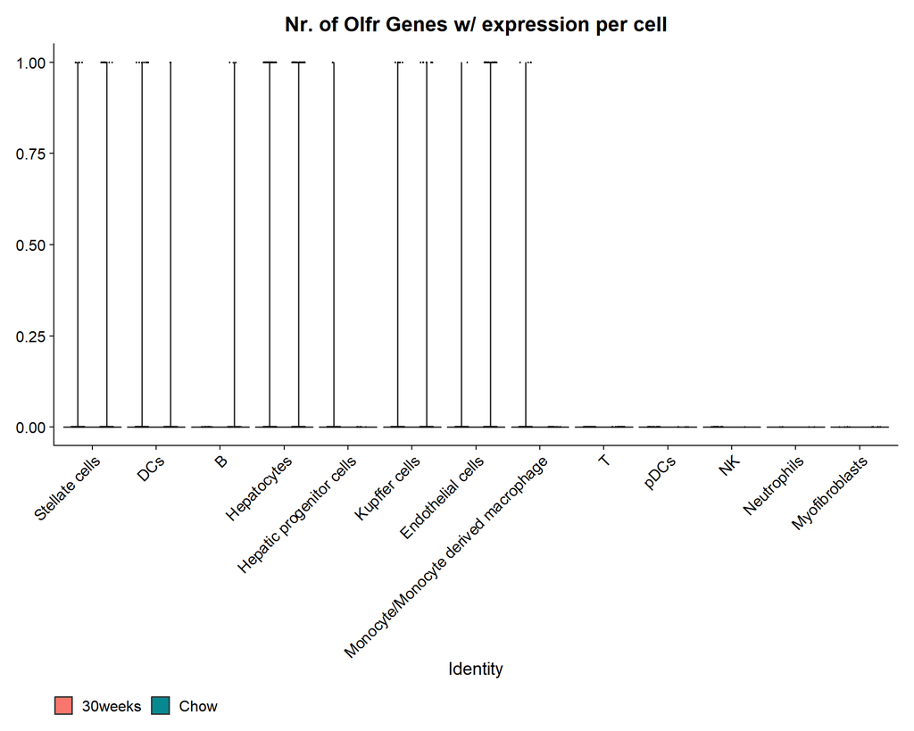

```r
sce$nFeature_Olfr <- Matrix::colSums(counts[olfr_genes, , drop = FALSE] > 0)

VlnPlot(sce, features = c("nFeature_Olfr"),group.by="celltype",split.by="time",sort = T)+
  ggtitle("Nr. of Olfr Genes w/ expression per cell")+
  theme(legend.position = "bottom") # these two metrics are also useful in log scale
```

```r
rowSums(counts[olfr_genes, , drop = FALSE] > 0) [rowSums(counts[olfr_genes, , drop = FALSE] > 0)>0]
```

```
      Olfr56 Olfr1372-ps1      Olfr750     Olfr1449      Olfr433     Olfr1029
           3           23            1            1            8            1
    Olfr1030     Olfr1033     Olfr1034      Olfr212      Olfr566      Olfr613
           1          116            7            8            1            1
     Olfr701      Olfr920
           7           17
```

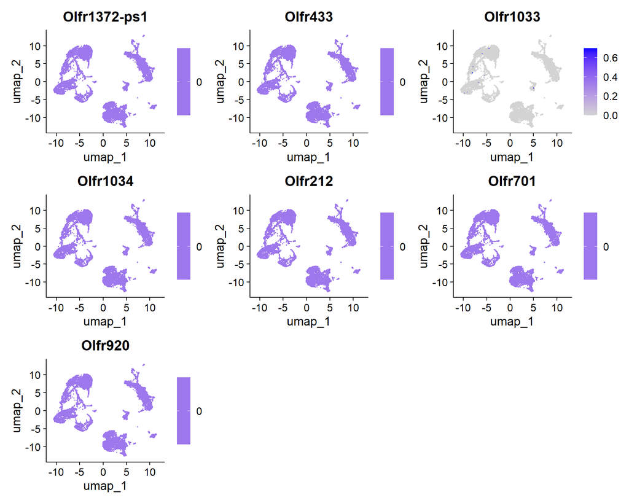

```r
Olfr_interest = names(rowSums(counts[olfr_genes, , drop = FALSE] > 0) [rowSums(counts[olfr_genes, , drop = FALSE] > 0)>0])

FeaturePlot(sce_umap, features = Olfr_interest)
```